# Код и выводы

**Комментарий ревьюера**

Вера, я вижу, исполнение твоего кода прерывается с синтаксической ошибкой:

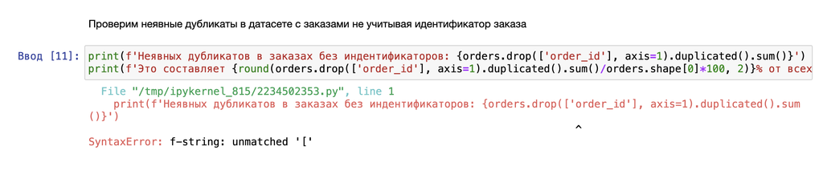

Перед отправкой проекта (особенно в случае работы локально или в другом окружении) стоит проверять работоспособность кода **на платформе** — это можно сделать, нажав на панели Jupiter Hub `Kernel` и `Restart & Run All` (см скриншот ниже).

[figure not shown]

Важно также убедиться, что все ячейки проекта исполнились - можно просто пролистать работу до конца и убедиться, что последняя ячейка исполнена. Такая проверка поможет тебе убедиться, что твоё решение будет должным образом воспроизведено во время ревью или во время передачи его заказчику - это очень важный этап, пренебрегать которым не стоит:)

На финальном проекте проверка воспроизводимости решения - одно из ключевых условий для начала работы над ним, поэтому перед отправкой работы на следующую итерацию ревью убедись в её работоспособности на платформе по инструкции выше.

# Исследовательский анализ данных в Python и проверка гипотез для сервиса Яндекс Афиша

Выполнила: Стрежнева Вера

Дата: 03.05.2025

### **Цели и задачи проекта**

- определить причину изменения пользовательского спроса (сезонность, другие предпочтения, другая аудитория)
- понять, какие события стали привлекать больше зрителей
- вычислить организаторов и площадки, которые выбились в лидеры
- проверить, отличаются ли активностью пользователи мобильной версии и компьютерной

### **Описание данных**

1. Датасет ***final_tickets_orders_df*** включает информацию обо всех заказах билетов, совершённых с двух типов устройств — мобильных и стационарных:
- `order_id` — уникальный идентификатор заказа.
- `user_id` — уникальный идентификатор пользователя.
- `created_dt_msk` — дата создания заказа (московское время).
- `created_ts_msk` — дата и время создания заказа (московское время).
- `event_id` — идентификатор мероприятия из таблицы events.
- `cinema_circuit` — сеть кинотеатров. Если не применимо, то здесь будет значение 'нет'.
- `age_limit` — возрастное ограничение мероприятия.
- `currency_code` — валюта оплаты, например rub для российских рублей.
- `device_type_canonical` — тип устройства, с которого был оформлен заказ, например mobile для мобильных устройств, desktop для стационарных.
- `revenue` — выручка от заказа.
- `service_name` — название билетного оператора.
- `tickets_count` — количество купленных билетов.
- `total` — общая сумма заказа.
- `days_since_prev`- количество дней с предыдущей покупки для каждого пользователя. Если покупки не было, то данные содержат пропуск.
2. Датасет ***final_tickets_events_df*** содержит информацию о событиях, включая город и регион события, а также информацию о площадке проведения мероприятия:
- `event_id` — уникальный идентификатор мероприятия.
- `event_name` — название мероприятия. Аналог поля event_name_code из исходной базы данных.
- `event_type_description` — описание типа мероприятия.
- `event_type_main` — основной тип мероприятия: театральная постановка, концерт и так далее.
- `organizers` — организаторы мероприятия.
- `region_name` — название региона.
- `city_name` — название города.
- `venue_id` — уникальный идентификатор площадки.
- `venue_name` — название площадки.
- `venue_address` — адрес площадки.
3. Датасет ***final_tickets_tenge_df*** с информацией о курсе тенге к российскому рублю за 2024 год. Значения в рублях представлено для 100 тенге. Датасет содержит такие поля:
- `nominal` — номинал (100 тенге).
- `data` — дата.
- `curs` — курс тенге к рублю.
- `cdx` — обозначение валюты (kzt).

### **Структура проекта**

1. Загрузка данных и знакомство с ними
2. Предобработка данных и подготовка их к исследованию
3. Исследовательский анализ данных
4. Статистический анализ данных
5. Общий вывод и рекомендации

```python
#подключим нужные библиотеки
import pandas as pd
import matplotlib.pyplot as plt
from scipy import stats as st
```

## 1. Загрузка данных и знакомство с ними

Для начала загрузим все нужные данные и изучим их. Проверим их целостность и соответствие описанию.

```python
# загрузим нужные датасеты
orders = pd.read_csv("https://code.s3.yandex.net/datasets/final_tickets_orders_df.csv")
events = pd.read_csv("https://code.s3.yandex.net/datasets/final_tickets_events_df.csv")
tenge = pd.read_csv("https://code.s3.yandex.net/datasets/final_tickets_tenge_df.csv")
```

```python
#изучим датасет с заказами
orders.head()
```

|  | order_id | user_id | created_dt_msk | created_ts_msk | event_id | cinema_circuit | age_limit | currency_code | device_type_canonical | revenue | service_name | tickets_count | total | days_since_prev |
| --- | --- | --- | --- | --- | --- | --- | --- | --- | --- | --- | --- | --- | --- | --- |
| 0 | 4359165 | 0002849b70a3ce2 | 2024-08-20 | 2024-08-20 16:08:03 | 169230 | нет | 16 | rub | mobile | 1521.94 | Край билетов | 4 | 10870.99 | NaN |
| 1 | 7965605 | 0005ca5e93f2cf4 | 2024-07-23 | 2024-07-23 18:36:24 | 237325 | нет | 0 | rub | mobile | 289.45 | Мой билет | 2 | 2067.51 | NaN |
| 2 | 7292370 | 0005ca5e93f2cf4 | 2024-10-06 | 2024-10-06 13:56:02 | 578454 | нет | 0 | rub | mobile | 1258.57 | За билетом! | 4 | 13984.16 | 75.0 |
| 3 | 1139875 | 000898990054619 | 2024-07-13 | 2024-07-13 19:40:48 | 387271 | нет | 0 | rub | mobile | 8.49 | Лови билет! | 2 | 212.28 | NaN |
| 4 | 972400 | 000898990054619 | 2024-10-04 | 2024-10-04 22:33:15 | 509453 | нет | 18 | rub | mobile | 1390.41 | Билеты без проблем | 3 | 10695.43 | 83.0 |

```python
orders.info()
```

```
<class 'pandas.core.frame.DataFrame'>
RangeIndex: 290849 entries, 0 to 290848
Data columns (total 14 columns):
 #   Column                 Non-Null Count   Dtype
---  ------                 --------------   -----
 0   order_id               290849 non-null  int64
 1   user_id                290849 non-null  object
 2   created_dt_msk         290849 non-null  object
 3   created_ts_msk         290849 non-null  object
 4   event_id               290849 non-null  int64
 5   cinema_circuit         290849 non-null  object
 6   age_limit              290849 non-null  int64
 7   currency_code          290849 non-null  object
 8   device_type_canonical  290849 non-null  object
 9   revenue                290849 non-null  float64
 10  service_name           290849 non-null  object
 11  tickets_count          290849 non-null  int64
 12  total                  290849 non-null  float64
 13  days_since_prev        268909 non-null  float64
dtypes: float64(3), int64(4), object(7)
memory usage: 31.1+ MB
```

Данные в датасете с заказами соответствуют изначальному описанию. Всего 290849 строк. Пропуски встречаются только в столбце `days_since_prev`, но это соответствует описанию этого столбца (пустое значение - значит прошлой покупки нет). Типы данных в целом соответствуют содержанию, но типы столбцом с датой можно поменять с object на datetime, а в столбцах `age_limit` и `days_since_prev` тип можно оптимизировать.

```python
#изучим датасет с событиями
events.head()
```

|  | event_id | event_name | event_type_description | event_type_main | organizers | region_name | city_name | city_id | venue_id | venue_name | venue_address |
| --- | --- | --- | --- | --- | --- | --- | --- | --- | --- | --- | --- |
| 0 | 4436 | e4f26fba-da77-4c61-928a-6c3e434d793f | спектакль | театр | №4893 | Североярская область | Озёрск | 2 | 1600 | Кладбище искусств "Проблема" и партнеры | наб. Загородная, д. 785 |
| 1 | 5785 | 5cc08a60-fdea-4186-9bb2-bffc3603fb77 | спектакль | театр | №1931 | Светополянский округ | Глиноград | 54 | 2196 | Лекции по искусству "Свет" Групп | ул. Ягодная, д. 942 |
| 2 | 8817 | 8e379a89-3a10-4811-ba06-ec22ebebe989 | спектакль | театр | №4896 | Североярская область | Озёрск | 2 | 4043 | Кинокомитет "Золотая" Инк | ш. Коммуны, д. 92 стр. 6 |
| 3 | 8849 | 682e3129-6a32-4952-9d8a-ef7f60d4c247 | спектакль | театр | №4960 | Каменевский регион | Глиногорск | 213 | 1987 | Выставка ремесел "Свет" Лтд | пер. Набережный, д. 35 |
| 4 | 8850 | d6e99176-c77f-4af0-9222-07c571f6c624 | спектакль | театр | №4770 | Лесодальний край | Родниковец | 55 | 4230 | Фестивальный проект "Листья" Групп | пер. Проезжий, д. 9 |

```python
events.info()
```

```
<class 'pandas.core.frame.DataFrame'>
RangeIndex: 22427 entries, 0 to 22426
Data columns (total 11 columns):
 #   Column                  Non-Null Count  Dtype
---  ------                  --------------  -----
 0   event_id                22427 non-null  int64
 1   event_name              22427 non-null  object
 2   event_type_description  22427 non-null  object
 3   event_type_main         22427 non-null  object
 4   organizers              22427 non-null  object
 5   region_name             22427 non-null  object
 6   city_name               22427 non-null  object
 7   city_id                 22427 non-null  int64
 8   venue_id                22427 non-null  int64
 9   venue_name              22427 non-null  object
 10  venue_address           22427 non-null  object
dtypes: int64(3), object(8)
memory usage: 1.9+ MB
```

Данные в датасете с событиями соответствуют изначальному описанию. Всего 22427 строк. Пропусков нет. Типы данных соответствуют содержанию.

```python
#изучим датасет с курсами валют
tenge.head()
```

|  | data | nominal | curs | cdx |
| --- | --- | --- | --- | --- |
| 0 | 2024-01-10 | 100 | 19.9391 | kzt |
| 1 | 2024-01-11 | 100 | 19.7255 | kzt |
| 2 | 2024-01-12 | 100 | 19.5839 | kzt |
| 3 | 2024-01-13 | 100 | 19.4501 | kzt |
| 4 | 2024-01-14 | 100 | 19.4501 | kzt |

```python
tenge.info()
```

```
<class 'pandas.core.frame.DataFrame'>
RangeIndex: 357 entries, 0 to 356
Data columns (total 4 columns):
 #   Column   Non-Null Count  Dtype
---  ------   --------------  -----
 0   data     357 non-null    object
 1   nominal  357 non-null    int64
 2   curs     357 non-null    float64
 3   cdx      357 non-null    object
dtypes: float64(1), int64(1), object(2)
memory usage: 11.3+ KB
```

Данные в датасете с курсами валют соответствуют изначальному описанию. Всего 357 значений. Пропусков нет. Тип в столбце с датой можно поменять на datetime, а тип в столбце `nominal` оптимизировать.

**Вывод:**

- все данные в датасетах соответствуют описанию
- всего почти 291 тысяча строк в датафрейме с заказами и 22,5 тысяч строк в датафрейме с событиями
- пропусков в данных нет
- тип столбцов с датами `created_dt_msk` и `created_ts_msk` в orders, `data` в tenge можно поменять с object на datetime
- в некоторых количественных столбцах типы можно оптимизировать под меньший размер

## 2. Предобработка данных и подготовка их к исследованию

Нужно проверить данные на наличие явных и неявных дубликатов, исправить типы данных, проверить уникальные значения в категориальных столбцах, в числовых столбцах проверить данные на выбросы, а также создать несколько новых столцов (с выручкой в рублях, выручка с одного билета, месяц заказа и сезон).

```python
#еще раз проверим данные на пропуски
print(f'Пропуски в датасете с заказами orders \n {orders.isna().sum()} \n')
print(f'Пропуски в датасете с событиями events \n {events.isna().sum()} \n')
print(f'Пропуски в датасете с курсами валют tenge \n {tenge.isna().sum()}')
```

```
Пропуски в датасете с заказами orders
 order_id                     0
user_id                      0
created_dt_msk               0
created_ts_msk               0
event_id                     0
cinema_circuit               0
age_limit                    0
currency_code                0
device_type_canonical        0
revenue                      0
service_name                 0
tickets_count                0
total                        0
days_since_prev          21940
dtype: int64

Пропуски в датасете с событиями events
 event_id                  0
event_name                0
event_type_description    0
event_type_main           0
organizers                0
region_name               0
city_name                 0
city_id                   0
venue_id                  0
venue_name                0
venue_address             0
dtype: int64

Пропуски в датасете с курсами валют tenge
 data       0
nominal    0
curs       0
cdx        0
dtype: int64
```

Как мы уже выявили на прошлом шаге, пропусков в данных, кроме столбца `days_since_prev`, нет.

**Теперь посмотрим на наличие явных дубликатов в датасетах:**

```python
print(f'Явные дубликаты в датасете с заказами orders \n {orders.duplicated().sum()} \n')
print(f'Явные дубликаты в датасете с событиями events \n {events.duplicated().sum()} \n')
print(f'Явные дубликаты в датасете с курсами валют tenge \n {tenge.duplicated().sum()}')
```

```
Явные дубликаты в датасете с заказами orders
 0

Явные дубликаты в датасете с событиями events
 0

Явные дубликаты в датасете с курсами валют tenge
 0
```

Явных дубликатов в данных нет.

Проверим неявные дубликаты в датасете с заказами не учитывая идентификатор заказа

```python
print(f"Неявных дубликатов в заказах без индентификаторов: {orders.drop(['order_id'], axis=1).duplicated().sum()}")
print(f"Это составляет {round(orders.drop(['order_id'], axis=1).duplicated().sum()/orders.shape[0]*100, 2)}% от всех данных")
```

```
Неявных дубликатов в заказах без индентификаторов: 30
Это составляет 0.01% от всех данных
```

Видим, что существует 30 строк с одинаковыми значениями во всех столбцах, кроме идентификатора заказа. Возможно, произошел сбой в данных и заказы одного пользователя записались несколько раз. Так как это составляет только 0,01% от всех данных, их можно просто удалить.

```python
orders = orders[~orders.drop(['order_id'], axis=1).duplicated()]
```

**Теперь изучим значения в категориальных столбцах**

```python
#проверяем для датасета с заказами
for x in ['cinema_circuit','age_limit','currency_code','device_type_canonical', 'service_name']:
    print(x, '\n', orders[x].unique())
```

```
cinema_circuit
 ['нет' 'Другое' 'Киномакс' 'КиноСити' 'Москино' 'ЦентрФильм']
age_limit
 [16  0 18 12  6]
currency_code
 ['rub' 'kzt']
device_type_canonical
 ['mobile' 'desktop']
service_name
 ['Край билетов' 'Мой билет' 'За билетом!' 'Лови билет!'
 'Билеты без проблем' 'Облачко' 'Лучшие билеты' 'Прачечная' 'Быстробилет'
 'Дом культуры' 'Весь в билетах' 'Билеты в руки' 'Тебе билет!'
 'Show_ticket' 'Городской дом культуры' 'Яблоко' 'Билет по телефону'
 'Выступления.ру' 'Росбилет' 'Шоу начинается!' 'Мир касс' 'Восьмёрка'
 'Телебилет' 'Crazy ticket!' 'Реестр' 'Быстрый кассир' 'КарандашРУ'
 'Радио ticket' 'Дырокол' 'Вперёд!' 'Кино билет' 'Цвет и билет' 'Зе Бест!'
 'Тех билет' 'Лимоны' 'Билеты в интернете']
```

Можно заметить, что в столбце с маркером сети кинотеатров есть категории "нет" и "другое". Скорее всего, это обозначение одного и того же случая - когда мероприятие не относится к сети кинотеатров. В остальных столбцах неявных дубликатов нет.

```python
#заменяем значения "другое" на "нет"
orders.loc[orders['cinema_circuit']=='Другое','cinema_circuit']='нет'
```

```python
#проверяем для датасета с событиями
for x in ['event_type_description','event_type_main','region_name']:
    print(x, '\n', sorted(events[x].unique()))
```

[output not shown]

Можно заметить, что в названиях регионов есть 'Речицкая область' и 'Речицкий регион'. Можно предположить, что это один и тот же регион, просто записаный по разному. В остальных категориальных столбцах нет неявных дубликатов.

```python
events.loc[events['region_name']=='Речицкий регион','region_name']='Речицкая область'
```

**Посмотрим на распределения в числовых столбцах и на наличие выбросов в датасете с заказами**

```python
#изучим статистики в столбце с выручкой
print(f"Статистики выручки в рублях \n {orders[orders['currency_code']=='rub']['revenue'].describe()}")
print(f"Статистики выручки в тенге \n {orders[orders['currency_code']=='kzt']['revenue'].describe()}")
```

```
Статистики выручки в рублях
 count    285750.000000
mean        547.590617
std         871.556472
min         -90.760000
25%         113.862500
50%         346.180000
75%         791.700000
max       81174.540000
Name: revenue, dtype: float64
Статистики выручки в тенге
 count     5069.000000
mean      4995.206767
std       4916.752776
min          0.000000
25%        518.100000
50%       3698.830000
75%       7397.660000
max      26425.860000
Name: revenue, dtype: float64
```

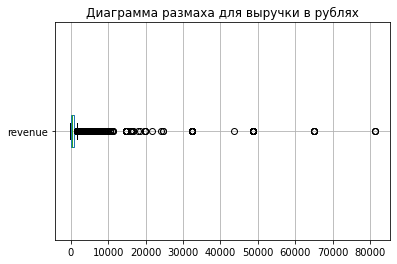

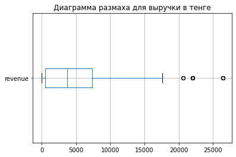

```python
orders[orders['currency_code']=='rub'].boxplot(column='revenue', vert=False)
plt.title('Диаграмма размаха для выручки в рублях')
plt.show()

orders[orders['currency_code']=='kzt'].boxplot(column='revenue', vert=False)
plt.title('Диаграмма размаха для выручки в тенге')
plt.show()
```

В выручке в рублях видим много выбросов, а также наличие отрицательных значений. Отрицательные значения могут означать возвраты.

Распределение в столбце с выручкой в тенге также содержит выбросы, но их намного меньше (но при этом и значений тут в целом тоже меньше, чем в рублях).

Отфильтруем значения в столбце по значению 99 перцентиля.

```python
orders_filtered = orders
orders_filtered[orders_filtered['currency_code']=='rub'] = orders[orders['currency_code']=='rub'][orders[orders['currency_code']=='rub']['revenue']<orders[orders['currency_code']=='rub']['revenue'].quantile(0.99)]
orders_filtered[orders_filtered['currency_code']=='kzt'] = orders[orders['currency_code']=='kzt'][orders[orders['currency_code']=='kzt']['revenue']<orders[orders['currency_code']=='kzt']['revenue'].quantile(0.99)]
```

```python
#изучим статистики в столбце с количеством билетов
print(f"Статистики в столбце с количеством билетов \n {orders_filtered['tickets_count'].describe()}")
```

```
Статистики в столбце с количеством билетов
 count    287736.000000
mean          2.739056
std           1.162224
min           1.000000
25%           2.000000
50%           3.000000
75%           3.000000
max          57.000000
Name: tickets_count, dtype: float64
```

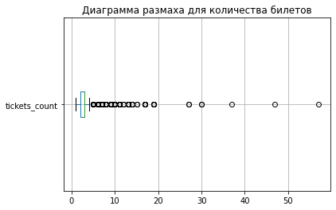

```python
orders_filtered.boxplot(column='tickets_count', vert=False)
plt.title('Диаграмма размаха для количества билетов')
plt.show()
```

Видим, что в количестве билетов также встречаются аномальные значения - максимально количество билетов в одном заказе 57. Также отфильтруем их по 99 перцентилю.

```python
orders_filtered= orders_filtered[orders_filtered['tickets_count']<orders_filtered['tickets_count'].quantile(0.99)]
```

**Оптимизируем типы данных**

```python
#поменяем тип столбцов с датами с object на datetime
orders_filtered['created_dt_msk'] = pd.to_datetime(orders_filtered['created_dt_msk'])
orders_filtered['created_ts_msk'] = pd.to_datetime(orders_filtered['created_ts_msk'])
tenge['data'] = pd.to_datetime(tenge['data'])
```

```python
#оптимизируем типы в некоторых количественных столбцах
orders_filtered['age_limit'] = pd.to_numeric(orders_filtered['age_limit'], downcast='integer')
orders_filtered['days_since_prev'] = pd.to_numeric(orders_filtered['days_since_prev'], downcast='integer')
tenge['nominal'] = pd.to_numeric(tenge['nominal'], downcast='integer')
```

**Создадим новые столбцы**

Нужно создать несколько новых столцов: с выручкой в рублях, выручка с одного билета, месяц заказа и сезон.

Сначала присоединим к датафрейму с заказами датафрейм с курсами валют по дате, а потом создадим новый столбец с выручкой в рублях.

```python
#объединяем датасеты
orders_rub = orders_filtered.merge(tenge, left_on='created_dt_msk', right_on='data', how='left')
```

```python
#создаем новый столбец с выручкой в рублях
orders_rub.loc[orders_rub['currency_code']=='rub','revenue_rub'] = orders_rub['revenue']
orders_rub.loc[orders_rub['currency_code']=='kzt', 'revenue_rub'] = orders_rub['revenue']*orders_rub['curs']/100
```

Создаем столбец с выручкой на один билет (по формуле: выручка в рублях/количество билетов)

```python
orders_rub['one_ticket_revenue_rub'] = orders_rub['revenue_rub']/orders_rub['tickets_count']
```

Выделим в отдельный столбец месяц оформления заказа

```python
orders_rub['month'] = orders_rub['created_dt_msk'].dt.month
```

Также создадим столбец с сезоном (зима, весна, лето, осень)

```python
def season(x):
    if x in [1,2,12]:
        return 'зима'
    if x in [3,4,5]:
        return 'весна'
    if x in [6,7,8]:
        return 'лето'
    else:
        return 'осень'

orders_rub['season'] = orders_rub['month'].apply(season)
```

```python
orders_rub.head()
```

|  | order_id | user_id | created_dt_msk | created_ts_msk | event_id | cinema_circuit | age_limit | currency_code | device_type_canonical | revenue | ... | total | days_since_prev | data | nominal | curs | cdx | revenue_rub | one_ticket_revenue_rub | month | season |
| --- | --- | --- | --- | --- | --- | --- | --- | --- | --- | --- | --- | --- | --- | --- | --- | --- | --- | --- | --- | --- | --- |
| 0 | 4359165.0 | 0002849b70a3ce2 | 2024-08-20 | 2024-08-20 16:08:03 | 169230.0 | нет | 16 | rub | mobile | 1521.94 | ... | 10870.99 | NaN | 2024-08-20 | 100 | 18.6972 | kzt | 1521.94 | 380.4850 | 8 | лето |
| 1 | 7965605.0 | 0005ca5e93f2cf4 | 2024-07-23 | 2024-07-23 18:36:24 | 237325.0 | нет | 0 | rub | mobile | 289.45 | ... | 2067.51 | NaN | 2024-07-23 | 100 | 18.3419 | kzt | 289.45 | 144.7250 | 7 | лето |
| 2 | 7292370.0 | 0005ca5e93f2cf4 | 2024-10-06 | 2024-10-06 13:56:02 | 578454.0 | нет | 0 | rub | mobile | 1258.57 | ... | 13984.16 | 75.0 | 2024-10-06 | 100 | 19.6475 | kzt | 1258.57 | 314.6425 | 10 | осень |
| 3 | 1139875.0 | 000898990054619 | 2024-07-13 | 2024-07-13 19:40:48 | 387271.0 | нет | 0 | rub | mobile | 8.49 | ... | 212.28 | NaN | 2024-07-13 | 100 | 18.5010 | kzt | 8.49 | 4.2450 | 7 | лето |
| 4 | 972400.0 | 000898990054619 | 2024-10-04 | 2024-10-04 22:33:15 | 509453.0 | нет | 18 | rub | mobile | 1390.41 | ... | 10695.43 | 83.0 | 2024-10-04 | 100 | 19.6648 | kzt | 1390.41 | 463.4700 | 10 | осень |

5 rows × 22 columns

```python
orders_rub.info()
```

```
<class 'pandas.core.frame.DataFrame'>
Int64Index: 283650 entries, 0 to 283649
Data columns (total 22 columns):
 #   Column                  Non-Null Count   Dtype
---  ------                  --------------   -----
 0   order_id                283650 non-null  float64
 1   user_id                 283650 non-null  object
 2   created_dt_msk          283650 non-null  datetime64[ns]
 3   created_ts_msk          283650 non-null  datetime64[ns]
 4   event_id                283650 non-null  float64
 5   cinema_circuit          283650 non-null  object
 6   age_limit               283650 non-null  int8
 7   currency_code           283650 non-null  object
 8   device_type_canonical   283650 non-null  object
 9   revenue                 283650 non-null  float64
 10  service_name            283650 non-null  object
 11  tickets_count           283650 non-null  float64
 12  total                   283650 non-null  float64
 13  days_since_prev         262246 non-null  float64
 14  data                    283650 non-null  datetime64[ns]
 15  nominal                 283650 non-null  int8
 16  curs                    283650 non-null  float64
 17  cdx                     283650 non-null  object
 18  revenue_rub             283650 non-null  float64
 19  one_ticket_revenue_rub  283650 non-null  float64
 20  month                   283650 non-null  int64
 21  season                  283650 non-null  object
dtypes: datetime64[ns](3), float64(9), int64(1), int8(2), object(7)
memory usage: 54.0+ MB
```

```python
print(f"Таким образом, после фильтрации мы лишились {round((1-orders_rub.shape[0]/orders.shape[0])*100, 2)}% строк от изначального количества")
```

```
Таким образом, после фильтрации мы лишились 2.47% строк от изначального количества
```

**Выводы:**

- пропусков в данных нет
- явных дубликатов нет
- были удалены 30 строк неявных дубликатов в датасете с заказами без id заказа
- были исправлены неявные дубликаты в значениях столбца `cinema_circuit` (значения "другое" заменены на "нет"), а также в столбце `region_name` "Речицкий регион" заменено на "Речицкая область"
- в столбцах с выручкой и количеством билетов были отфильтрованы выбросы по 99 перцентилю
- в столбцах с датами поменяли тип данных с object на datetime
- в некоторых числовых столбцах оптимизировали тип даных на меньший по размеру
- создали новые столбцы:
  - revenue_rub — выручка с заказа в рублях.
  - one_ticket_revenue_rub — выручка с продажи одного билета на мероприятие.
  - month — месяц оформления заказа.
  - season — информация о сезонности, включая такие категории, как: 'лето', 'осень', 'зима', 'весна'
- в итоге получился датафрейм с 283650 строками
- потери от изначального количества составили 2,47%.

## 3. Исследовательский анализ данных

**1. Анализ распределения заказов по сегментам и их сезонные изменения**

Анализ дашборда показал, что в данных наблюдается сезонность — осенью количество заказов увеличивается. На этой стадии исследовательского анализа изучим изменение пользовательской активности или пользовательского интереса в связи с сезонностью. Динамику проанализируем в разрезе типа мероприятия, типа устройства, категории мероприятия по возрастному ограничению.

***Для начала покажем для каждого месяца количество заказов***

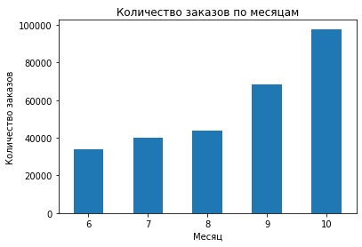

```python
monthly_orders = orders_rub.groupby('month')['order_id'].count().sort_values()
monthly_orders.plot(kind='bar', title='Количество заказов по месяцам', rot=0, ylabel='Количество заказов', xlabel='Месяц')
plt.show()
```

С помощью графика подтверждаем то, что с приходом осени количество заказов сильно возросло.

***Теперь посмотрим количество заказов в разрезе типов устройств, типов мероприятий и возрастной группы по сезонам.***

```python
#функция для добавления подписей к графикам
def graph (ax):
    plt.figure(figsize=(12, 12))
    for bars in ax.containers:
        for bar in bars:
            height = bar.get_height()
            if height > 1:  # Подписываем только если больше 1% (чтобы не загромождать)
                ax.annotate(f'{height:.1f}%',
                        xy=(bar.get_x() + bar.get_width() / 2, bar.get_y() + height / 2),
                        ha='center', va='center', fontsize=8, color='white')
    plt.tight_layout()
    plt.show()
```

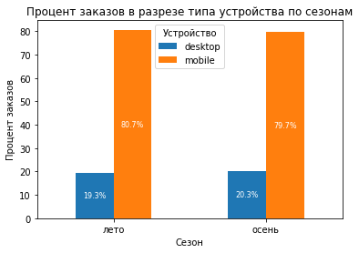

```python
#для устройств
device_orders = orders_rub.groupby(['season', 'device_type_canonical'])['order_id'].count()/orders_rub.groupby(['season'])['order_id'].count()*100
ax = device_orders.unstack(1).plot(kind='bar', rot=0, title='Процент заказов в разрезе типа устройства по сезонам', xlabel='Сезон', ylabel='Процент заказов')
plt.legend(title='Устройство',loc='upper center')
graph(ax)
```

Для удобства далее к датафрейму с заказами присоединим датасет с событиями

```python
ord_evnt_rub = orders_rub.merge(events, on='event_id', how='left')
```

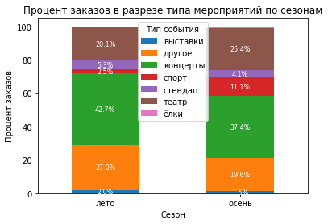

```python
#смотрим распредление количества заказов для типов мероприятий по сезонам
events_orders = ord_evnt_rub.groupby(['season', 'event_type_main'])['order_id'].count()/ord_evnt_rub.groupby(['season'])['order_id'].count()*100
ax = events_orders.unstack(1).plot(kind='bar', stacked=True, rot=0, title='Процент заказов в разрезе типа мероприятий по сезонам', xlabel='Сезон', ylabel='Процент заказов')
plt.legend(title='Тип события',loc='upper center')
graph(ax)
```

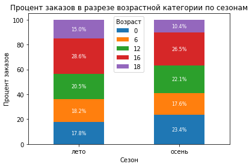

```python
#смотрим распредление по возрастным категориям
age_orders = ord_evnt_rub.groupby(['season', 'age_limit'])['order_id'].count()/ord_evnt_rub.groupby(['season'])['order_id'].count()*100
ax = age_orders.unstack(1).plot(kind='bar', stacked=True, rot=0, title='Процент заказов в разрезе возрастной категории по сезонам', xlabel='Сезон', ylabel='Процент заказов')
plt.legend(title='Возраст',loc='upper center')
graph(ax)
```

- Видим, что в разрезе устройств динамика количества заказов с началом осени изменилась лишь на 1%: 79,7% заказов совершаются с мобильных устройств и 20,3% с компьютеров.
- По типам мероприятий можно заметить, что процент категорий "театр" (примерно на 5%) и "спорт" (примерно на 9%) выросли в осенний период, когда проценты других типов сократились.
- В возрастных категориях осенью выросла доля мероприятий 0+ (примерно на 6%) и 12+ (примерно на 2%). А сократилась больше всего категория 18+ (на 4.6%)

***Изучим изменение выручки с продажи одного билета в зависимости от типа мероприятия летом и осенью.***

```python
#посмотрим просто среднюю выручку с одного билета по сезонам в разрезе типов мероприятий
pd.pivot_table(ord_evnt_rub, index=['season', 'event_type_main'], values='one_ticket_revenue_rub', aggfunc='mean')
```

| season | event_type_main | one_ticket_revenue_rub |
| --- | --- | --- |
| лето | выставки | 86.392075 |
|  | другое | 77.087439 |
|  | концерты | 303.191838 |
|  | спорт | 50.965311 |
|  | стендап | 219.366179 |
|  | театр | 214.748594 |
|  | ёлки | 273.779500 |
| осень | выставки | 90.706737 |
|  | другое | 75.571298 |
|  | концерты | 268.350536 |
|  | спорт | 50.027741 |
|  | стендап | 231.809494 |
|  | театр | 176.488498 |
|  | ёлки | 232.569401 |

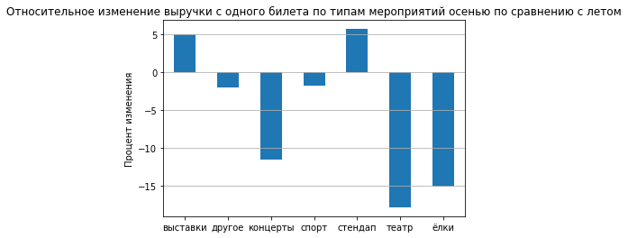

```python
#теперь посчитаем относительное изменение
autumn_tickets = ord_evnt_rub[ord_evnt_rub['season']=='осень'].groupby('event_type_main')['one_ticket_revenue_rub'].mean()
summer_tickets = ord_evnt_rub[ord_evnt_rub['season']=='лето'].groupby('event_type_main')['one_ticket_revenue_rub'].mean()
diff_tickets = (autumn_tickets-summer_tickets)/summer_tickets*100
diff_tickets.plot(kind='bar', rot=0, title='Относительное изменение выручки с одного билета по типам мероприятий осенью по сравнению с летом', xlabel='', ylabel='Процент изменения')
plt.grid(axis='y')
plt.show()
```

Сильнее всего упала выручка с одного билета в категории "театр" (около 20%), несмотря на то, что количество заказов в этой категории выросло. В категории "спорт", в которой так же наблюдалось увеличение количества заказов, выручка также снизилась примерно на 2%. В целом, почти по всем категориям, кроме выставок и стендапа, выручка упала.

**Таким образом:**

- процент количества заказов в разрезе устройств почти не поменялся в другом сезоне
- увеличился процент заказов в категориях театр и спорт, хотя отмечается падение выручки с одного билета в них
- процент заказов в категориях 0+ и 12+ вырос осенью, а 18+ сократился примерно на 5%

**2. Осенняя активность пользователей**

Изучим активность пользователей осенью 2024 (сентябрь и октябрь).

***Проанализируем динамику изменений по дням***

Построим таблицу с общим числом заказов, количеством активных пользователей DAU, средним числом заказов на одного пользователя и средней стоимостью одного билета по дням. Далее по этим данным простоим линейные графики.

```python
#сделаем таблицу
autumn = ord_evnt_rub[ord_evnt_rub['season']=='осень']
pivot_dinamic = autumn.groupby('created_dt_msk').agg(orders_per_day=('order_id', 'count'), dau=('user_id', 'nunique'), avg_ticket_price=('one_ticket_revenue_rub', 'mean'))
pivot_dinamic['avg_orders_per_user'] = pivot_dinamic['orders_per_day'] / pivot_dinamic['dau']
pivot_dinamic
```

| created_dt_msk | orders_per_day | dau | avg_ticket_price | avg_orders_per_user |
| --- | --- | --- | --- | --- |
| 2024-09-01 | 1302 | 559 | 200.713427 | 2.329159 |
| 2024-09-02 | 1367 | 570 | 189.860861 | 2.398246 |
| 2024-09-03 | 4991 | 770 | 80.839095 | 6.481818 |
| 2024-09-04 | 1750 | 677 | 178.217183 | 2.584934 |
| 2024-09-05 | 1924 | 733 | 189.978144 | 2.624829 |
| ... | ... | ... | ... | ... |
| 2024-10-27 | 2819 | 1025 | 187.365642 | 2.750244 |
| 2024-10-28 | 2797 | 975 | 171.683008 | 2.868718 |
| 2024-10-29 | 2800 | 994 | 178.537347 | 2.816901 |
| 2024-10-30 | 2880 | 1023 | 183.371479 | 2.815249 |
| 2024-10-31 | 5924 | 1264 | 150.756600 | 4.686709 |

61 rows × 4 columns

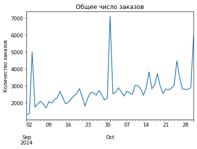

```python
pivot_dinamic['orders_per_day'].plot(kind='line', title='Общее число заказов', xlabel='', ylabel='Количество заказов')
plt.show()
```

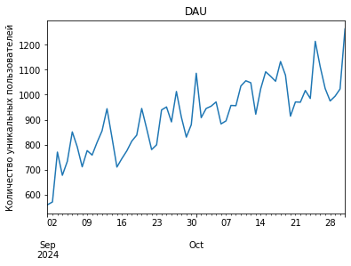

```python
pivot_dinamic['dau'].plot(kind='line', title='DAU', xlabel='',ylabel='Количество уникальных пользователей')
plt.show()
```

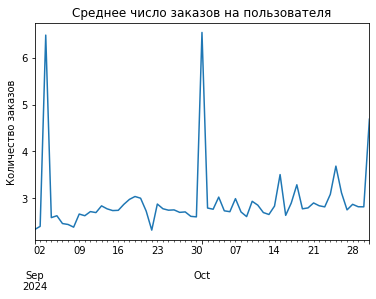

```python
pivot_dinamic['avg_orders_per_user'].plot(kind='line', title='Среднее число заказов на пользователя', xlabel='', ylabel='Количество заказов')
plt.show()
```

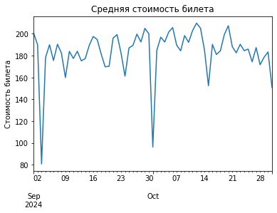

```python
pivot_dinamic['avg_ticket_price'].plot(kind='line', title='Средняя стоимость билета', xlabel='', ylabel='Стоимость билета')
plt.show()
```

***Теперь посмотрим на активность пользователей в будние дни и в выходные***

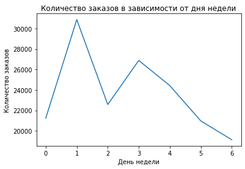

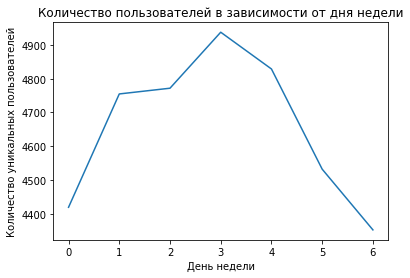

```python
#создаем столбец с днем недели
autumn['weekday'] = autumn['created_dt_msk'].dt.weekday

#считаем количество заказов
week_orders = autumn.groupby('weekday')['order_id'].count()
week_orders.plot(kind='line', title='Количество заказов в зависимости от дня недели', xlabel='День недели', ylabel='Количество заказов')
plt.show()

#считаем количество пользователей
week_users = autumn.groupby('weekday')['user_id'].nunique()
week_users.plot(kind='line', title='Количество пользователей в зависимости от дня недели', xlabel='День недели', ylabel='Количество уникальных пользователей')
plt.show()
```

- в целом виден спад и в количестве заказов, и в количестве пользователей к выходным по сравнению с будними днями: то есть если в начале недели было около 21 тыс. заказов и около 4410 пользователей, то в конце видим менее 19 тыс. заказов и менее 4350 пользователей.
- самое большое количество заказов совершается во вторник - около 31 тысячи
- больше всего уникальных пользователей наблюдается в четверг - около 4950.

## 3. Популярные события и партнёры

Изучим, как события распределены по регионам и партнерам. Это позволит выделить ключевые регионы и партнёров, которые вносят наибольший вклад в выручку.

***Посмотрим распределение событий по регионам***

```python
region_events = ord_evnt_rub.groupby('region_name').agg(unique_events=('event_id', 'nunique'), total_orders=('order_id', 'nunique'))
region_events['percantage_events'] = region_events['unique_events']/region_events['unique_events'].sum()*100
region_events['percantage_orders'] = region_events['total_orders']/region_events['total_orders'].sum()*100
region_10_sort_events = region_events.sort_values(by='percantage_events', ascending=False).head(10)
print('Топ-10 регионов по количеству уникальных событий')
display(region_10_sort_events)
region_10_sort_orders = region_events.sort_values(by='percantage_orders', ascending=False).head(10)
print('Топ-10 регионов по количеству заказов')
region_10_sort_orders
```

```
Топ-10 регионов по количеству уникальных событий
```

| region_name | unique_events | total_orders | percantage_events | percantage_orders |
| --- | --- | --- | --- | --- |
| Каменевский регион | 5916 | 88463 | 26.585180 | 31.213459 |
| Североярская область | 3777 | 42987 | 16.972992 | 15.167618 |
| Широковская область | 1227 | 15866 | 5.513863 | 5.598191 |
| Светополянский округ | 1069 | 7416 | 4.803847 | 2.616676 |
| Речиновская область | 701 | 6188 | 3.150137 | 2.183386 |
| Травяная область | 679 | 4960 | 3.051274 | 1.750096 |
| Горицветская область | 548 | 5087 | 2.462589 | 1.794907 |
| Серебринская область | 538 | 5499 | 2.417652 | 1.940278 |
| Яблоневская область | 531 | 6054 | 2.386195 | 2.136105 |
| Тепляковская область | 525 | 4296 | 2.359232 | 1.515809 |

```
Топ-10 регионов по количеству заказов
```

| region_name | unique_events | total_orders | percantage_events | percantage_orders |
| --- | --- | --- | --- | --- |
| Каменевский регион | 5916 | 88463 | 26.585180 | 31.213459 |
| Североярская область | 3777 | 42987 | 16.972992 | 15.167618 |
| Широковская область | 1227 | 15866 | 5.513863 | 5.598191 |
| Медовская область | 502 | 13586 | 2.255876 | 4.793711 |
| Озернинский край | 346 | 10244 | 1.554847 | 3.614513 |
| Светополянский округ | 1069 | 7416 | 4.803847 | 2.616676 |
| Малиновоярский округ | 163 | 6251 | 0.732486 | 2.205615 |
| Речиновская область | 701 | 6188 | 3.150137 | 2.183386 |
| Солнечноземская область | 519 | 6143 | 2.332270 | 2.167508 |
| Яблоневская область | 531 | 6054 | 2.386195 | 2.136105 |

***Посмотрим распределение событий по билетным партнёрам***

```python
service_events = ord_evnt_rub.groupby('service_name').agg(unique_events=('event_id', 'nunique'), total_orders=('order_id', 'nunique'), total_revenue=('revenue_rub', 'sum'))
service_events['total_revenue'] = round(service_events['total_revenue'],0)
service_events['percantage_events'] = service_events['unique_events']/service_events['unique_events'].sum()*100
service_events['percantage_orders'] = service_events['total_orders']/service_events['total_orders'].sum()*100
service_events['percantage_revenue'] = service_events['total_revenue']/service_events['total_revenue'].sum()*100
service_10_sort_events = service_events.sort_values(by='percantage_events', ascending=False).head(10)
print('Топ-10 билетных сервисов по количеству уникальных событий')
display(service_10_sort_events)
service_10_sort_orders = service_events.sort_values(by='percantage_orders', ascending=False).head(10)
print('Топ-10 билетных сервисов по количеству заказов')
display(service_10_sort_orders)
print('Топ-10 билетных сервисов по выручке')
service_10_sort_revenue = service_events.sort_values(by='percantage_revenue', ascending=False).head(10)
service_10_sort_revenue
```

```
Топ-10 билетных сервисов по количеству уникальных событий
```

| service_name | unique_events | total_orders | total_revenue | percantage_events | percantage_orders | percantage_revenue |
| --- | --- | --- | --- | --- | --- | --- |
| Лови билет! | 4845 | 40210 | 16256700.0 | 19.945659 | 14.175921 | 11.213544 |
| Билеты без проблем | 4236 | 61931 | 23578296.0 | 17.438557 | 21.833598 | 16.263834 |
| Билеты в руки | 3521 | 39610 | 12787985.0 | 14.495080 | 13.964393 | 8.820895 |
| Облачко | 2323 | 26198 | 18328313.0 | 9.563213 | 9.236030 | 12.642501 |
| Лучшие билеты | 1756 | 17550 | 2642979.0 | 7.229015 | 6.187203 | 1.823074 |
| Мой билет | 1294 | 33838 | 20920900.0 | 5.327076 | 11.929491 | 14.430816 |
| Тебе билет! | 1054 | 5095 | 2861090.0 | 4.339056 | 1.796228 | 1.973522 |
| Прачечная | 1025 | 10060 | 4637211.0 | 4.219670 | 3.546624 | 3.198655 |
| Весь в билетах | 850 | 16205 | 16118964.0 | 3.499238 | 5.713027 | 11.118537 |
| Яблоко | 712 | 4936 | 3783154.0 | 2.931127 | 1.740173 | 2.609543 |

```
Топ-10 билетных сервисов по количеству заказов
```

| service_name | unique_events | total_orders | total_revenue | percantage_events | percantage_orders | percantage_revenue |
| --- | --- | --- | --- | --- | --- | --- |
| Билеты без проблем | 4236 | 61931 | 23578296.0 | 17.438557 | 21.833598 | 16.263834 |
| Лови билет! | 4845 | 40210 | 16256700.0 | 19.945659 | 14.175921 | 11.213544 |
| Билеты в руки | 3521 | 39610 | 12787985.0 | 14.495080 | 13.964393 | 8.820895 |
| Мой билет | 1294 | 33838 | 20920900.0 | 5.327076 | 11.929491 | 14.430816 |
| Облачко | 2323 | 26198 | 18328313.0 | 9.563213 | 9.236030 | 12.642501 |
| Лучшие билеты | 1756 | 17550 | 2642979.0 | 7.229015 | 6.187203 | 1.823074 |
| Весь в билетах | 850 | 16205 | 16118964.0 | 3.499238 | 5.713027 | 11.118537 |
| Прачечная | 1025 | 10060 | 4637211.0 | 4.219670 | 3.546624 | 3.198655 |
| Край билетов | 251 | 6031 | 6260399.0 | 1.033305 | 2.126212 | 4.318297 |
| Тебе билет! | 1054 | 5095 | 2861090.0 | 4.339056 | 1.796228 | 1.973522 |

```
Топ-10 билетных сервисов по выручке
```

| service_name | unique_events | total_orders | total_revenue | percantage_events | percantage_orders | percantage_revenue |
| --- | --- | --- | --- | --- | --- | --- |
| Билеты без проблем | 4236 | 61931 | 23578296.0 | 17.438557 | 21.833598 | 16.263834 |
| Мой билет | 1294 | 33838 | 20920900.0 | 5.327076 | 11.929491 | 14.430816 |
| Облачко | 2323 | 26198 | 18328313.0 | 9.563213 | 9.236030 | 12.642501 |
| Лови билет! | 4845 | 40210 | 16256700.0 | 19.945659 | 14.175921 | 11.213544 |
| Весь в билетах | 850 | 16205 | 16118964.0 | 3.499238 | 5.713027 | 11.118537 |
| Билеты в руки | 3521 | 39610 | 12787985.0 | 14.495080 | 13.964393 | 8.820895 |
| Край билетов | 251 | 6031 | 6260399.0 | 1.033305 | 2.126212 | 4.318297 |
| Прачечная | 1025 | 10060 | 4637211.0 | 4.219670 | 3.546624 | 3.198655 |
| Дом культуры | 272 | 4375 | 4296649.0 | 1.119756 | 1.542394 | 2.963742 |
| Яблоко | 712 | 4936 | 3783154.0 | 2.931127 | 1.740173 | 2.609543 |

## 4. Статистический анализ данных

Нужно отдельно проверить несколько гипотез относительно активности пользователей мобильных и стационарных устройств. Проверим две гипотезы, которые предполагают большую активность пользователей мобильных устройств:

- Среднее количество заказов на одного пользователя мобильного приложения выше по сравнению с пользователями стационарных устройств.
- Среднее время между заказами пользователей мобильных приложений выше по сравнению с пользователями стационарных устройств.

Проверять будем за осенний период.

```python
#выделим проверяемые выборки
mobile = autumn[autumn['device_type_canonical']=='mobile'].copy()
desktop = autumn[autumn['device_type_canonical']=='desktop'].copy()
```

***Изучим проверяемые данные для первой гипотезы***

В каждой группе посчитаем для каждого пользователя количество заказов и посмотрим распределение этих данных.

```python
mobile_user_orders = mobile.groupby('user_id')['order_id'].nunique()
mobile_user_orders = pd.DataFrame({'user_id':mobile_user_orders.index, 'total_orders':mobile_user_orders.values})
```

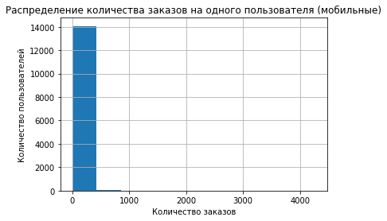

```python
mobile_user_orders['total_orders'].hist()
plt.title('Распределение количества заказов на одного пользователя (мобильные)')
plt.xlabel('Количество заказов')
plt.ylabel('Количество пользователей')
plt.show()
```

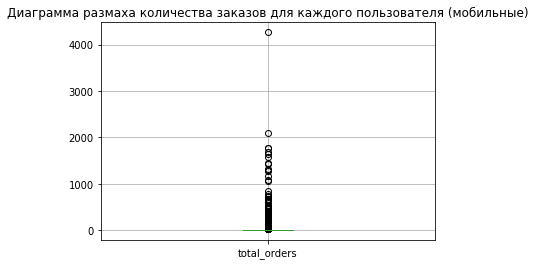

```python
mobile_user_orders.boxplot(column='total_orders')
plt.title('Диаграмма размаха количества заказов для каждого пользователя (мобильные)')
plt.show()
```

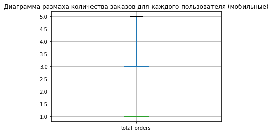

```python
#отфильтруем выбросы по 80 перцентилю (почти по границе ящика с усами)
mobile_user_orders = mobile_user_orders[mobile_user_orders['total_orders']<mobile_user_orders['total_orders'].quantile(0.80)]
mobile_user_orders.boxplot(column='total_orders')
plt.title('Диаграмма размаха количества заказов для каждого пользователя (мобильные)')
plt.show()
```

```python
mobile_user_orders['total_orders'].describe()
```

```
count    11121.000000
mean         1.904415
std          1.195743
min          1.000000
25%          1.000000
50%          1.000000
75%          3.000000
max          5.000000
Name: total_orders, dtype: float64
```

```python
#для стационарных пользователей
desktop_user_orders = desktop.groupby('user_id')['order_id'].nunique()
desktop_user_orders = pd.DataFrame({'user_id':desktop_user_orders.index, 'total_orders':desktop_user_orders.values})
```

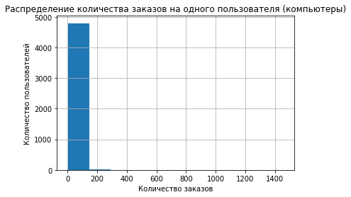

```python
desktop_user_orders['total_orders'].hist()
plt.title('Распределение количества заказов на одного пользователя (компьютеры)')
plt.xlabel('Количество заказов')
plt.ylabel('Количество пользователей')
plt.show()
```

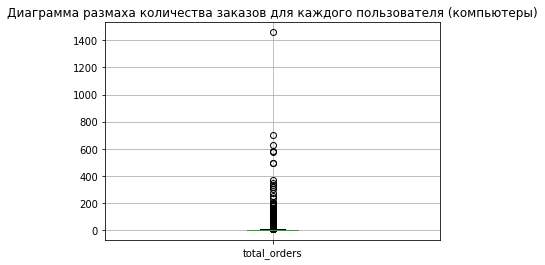

```python
desktop_user_orders.boxplot(column='total_orders')
plt.title('Диаграмма размаха количества заказов для каждого пользователя (компьютеры)')
plt.show()
```

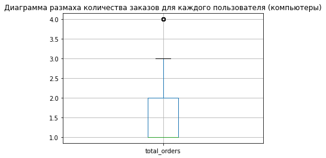

```python
#отфильтруем выбросы по 80 перцентилю (почти по границе ящика с усами)
desktop_user_orders = desktop_user_orders[desktop_user_orders['total_orders']<desktop_user_orders['total_orders'].quantile(0.80)]
desktop_user_orders.boxplot(column='total_orders')
plt.title('Диаграмма размаха количества заказов для каждого пользователя (компьютеры)')
plt.show()
```

```python
desktop_user_orders['total_orders'].describe()
```

```
count    3811.000000
mean        1.715560
std         0.959777
min         1.000000
25%         1.000000
50%         1.000000
75%         2.000000
max         4.000000
Name: total_orders, dtype: float64
```

Видим, что обе выборки содержали выбросы, но после их удаления по 80 перцентилю, статистики в группах стали сопоставимыми. Но для мобильных устройств среднее действительно выше, осталось проверить это статистическим тестом.

***Проверим первую гипотезу***

Гипотезы выглядят так: H0 - среднее количество заказов на одного пользователя мобильного приложения *не выше* среднего количества заказов на одного пользователя стационарных устройств. H1 - среднее количество заказов на одного пользователя мобильного приложения *выше* по сравнению с пользователями стационарных устройств.

Для проверки этой гипотезы будем использовать статистический тест T-тест Уэлча, так как он позволяет проверить равенство средних для выборок,а также для него не обязательно знать дисперсию выборок. Уровень значимости выберем стандартный: 0,05.

```python
alpha=0.05
results = st.ttest_ind(mobile_user_orders['total_orders'],
                                desktop_user_orders['total_orders'],
                                equal_var=False, alternative='greater')

if results.pvalue<alpha:
    print(f"Нулевую гипотезу о равенстве среднего количества заказов на пользователя в мобильной версии и компьютерной отвергаем, так как pvalue {round(results.pvalue,10)} < уровня значимости {alpha}")
else:
    print('Нулевую гипотезу о равенстве среднего количества заказов на пользователя в мобильной версии и компьютерной не можем отвергнуть')
```

```
Нулевую гипотезу о равенстве среднего количества заказов на пользователя в мобильной версии и компьютерной отвергаем, так как pvalue 0.0 < уровня значимости 0.05
```

Таким образом, предположение о том, что среднее количество заказов на одного пользователя с мобильных устройств больше, чем с компьютеров, отвергнуть не можем.

***Изучим данные для второй гипотезы***

Сначала сделаем датасет со средним временем между заказами для каждого пользователя и посмотрим статистики и распределение

```python
#мобильные устройства
mobile_days = mobile.groupby('user_id')['days_since_prev'].mean()
mobile_days = pd.DataFrame({'user_id':mobile_days.index, 'days_since_prev':mobile_days.values})
```

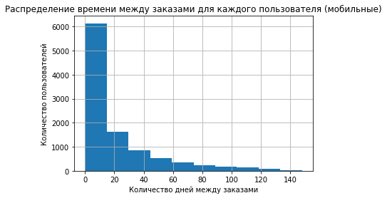

```python
mobile_days['days_since_prev'].hist()
plt.title('Распределение времени между заказами для каждого пользователя (мобильные)')
plt.xlabel('Количество дней между заказами')
plt.ylabel('Количество пользователей')
plt.show()
```

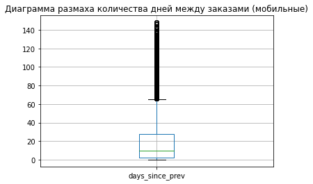

```python
mobile_days.boxplot(column='days_since_prev')
plt.title('Диаграмма размаха количества дней между заказами (мобильные)')
plt.show()
```

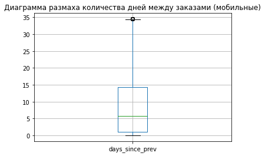

```python
#отфильтруем выбросы по 80 перцентилю (почти по границе ящика с усами)
mobile_days = mobile_days[mobile_days['days_since_prev']<mobile_days['days_since_prev'].quantile(0.80)]
mobile_days.boxplot(column='days_since_prev')
plt.title('Диаграмма размаха количества дней между заказами (мобильные)')
plt.show()
```

```python
mobile_days.describe()
```

|  | days_since_prev |
| --- | --- |
| count | 8098.000000 |
| mean | 8.959109 |
| std | 9.257745 |
| min | 0.000000 |
| 25% | 1.004630 |
| 50% | 5.839744 |
| 75% | 14.393750 |
| max | 34.500000 |

```python
#компьютеры
desktop_days = desktop.groupby('user_id')['days_since_prev'].mean()
desktop_days = pd.DataFrame({'user_id':desktop_days.index, 'days_since_prev':desktop_days.values})
```

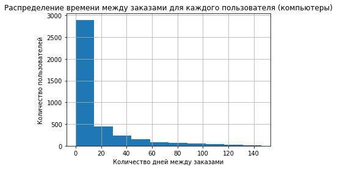

```python
desktop_days['days_since_prev'].hist()
plt.title('Распределение времени между заказами для каждого пользователя (компьютеры)')
plt.xlabel('Количество дней между заказами')
plt.ylabel('Количество пользователей')
plt.show()
```

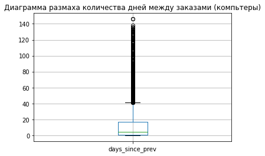

```python
desktop_days.boxplot(column='days_since_prev')
plt.title('Диаграмма размаха количества дней между заказами (компьтеры)')
plt.show()
```

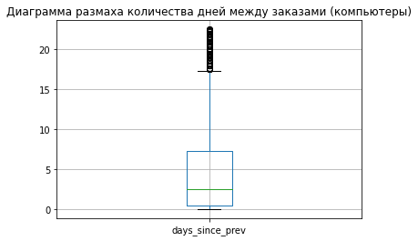

```python
#отфильтруем выбросы по 80 перцентилю (почти по границе ящика с усами)
desktop_days = desktop_days[desktop_days['days_since_prev']<desktop_days['days_since_prev'].quantile(0.80)]
desktop_days.boxplot(column='days_since_prev')
plt.title('Диаграмма размаха количества дней между заказами (компьютеры)')
plt.show()
```

```python
desktop_days['days_since_prev'].describe()
```

```
count    3198.000000
mean        4.866879
std         5.655458
min         0.000000
25%         0.500000
50%         2.500000
75%         7.250000
max        22.500000
Name: days_since_prev, dtype: float64
```

***Проводим статистический тест для второй гипотезы***

Гипотезы звучат так: H0 - среднее время между заказами пользователей мобильных приложений не выше среднего времени между заказами пользователей стационарных устройств. H1 - среднее время между заказами пользователей мобильных приложений выше по сравнению с пользователями стационарных устройств.

Так как данные мы очистили от выбросов, можно использовать t-тест Уэлча. Он позволяет проверить равенство средних для выборок, а также для него не обязательно знать дисперсию выборок. Уровень значимости 0.05.

```python
alpha=0.05
results = st.ttest_ind(mobile_days['days_since_prev'],
                                desktop_days['days_since_prev'],
                                equal_var=False, alternative='greater')

if results.pvalue<alpha:
    print(f"Нулевую гипотезу о равенстве среднего времени между заказами пользователей в мобильной версии и компьютерной отвергаем, так как pvalue {results.pvalue} < уровня значимости {alpha}")
else:
    print('Нулевую гипотезу о равенстве среднего времени между заказами пользователей в мобильной версии и компьютерной не можем отвергнуть')
```

```
Нулевую гипотезу о равенстве среднего времени между заказами пользователей в мобильной версии и компьютерной отвергаем, так как pvalue 5.557390491255039e-172 < уровня значимости 0.05
```

Таким образом, среднее время между заказами пользователей на мобильных устройствах больше, чем на компьютерах.

## 5. Общий вывод и рекомендации

## Общий вывод

**Информация о данных:**

В рамках анализа были использованы два основных датасета: с заказами (около 291 тыс. строк) и с событиями (около 22,5 тыс. строк). Пропусков и явных дубликатов в данных не обнаружено. Были устранены неявные дубликаты, приведены типы данных к оптимальным форматам, созданы дополнительные признаки (сезонность, средняя выручка за билет и выручка в рублях и т.д.), а также проведена фильтрация выбросов по выручке и количеству билетов.

**Основные результаты анализа:**

- Спрос: осенью наблюдается рост количества заказов, активных пользователей и среднего количества заказов на одного пользователя, особенно с мобильных устройств. Однако средняя выручка с одного билета при этом снижается.
- Популярность мероприятий: увеличился процент заказов в категориях «театр» и «спорт», но снизилась средняя выручка с одного билета в этих категориях. Также осенью выросла доля заказов на мероприятия с возрастными ограничениями 0+ и 12+, а доля заказов на мероприятия 18+ снизилась примерно на 5%.
- Средний чек: несмотря на рост заказов, наблюдается общее снижение средней выручки с одного билета.
- Пользовательская активность: больше всего заказов оформляется во вторник, больше уникальных пользователей — по четвергам. Активность пользователей заметно снижается в выходные дни.
- Регионы и партнёры: лидеры по числу уникальных событий и заказов — Каменевский регион и Североярская область. Среди партнёров — сервисы «Билеты без проблем», «Лови билет!», «Облачко» и «Мой билет». Эти же сервисы входят в топ по выручке.

**Проверка гипотез:**

- Гипотеза о среднем количестве заказов: нулевая гипотеза о равенстве среднего количества заказов на пользователя с мобильных и стационарных устройств была отвергнута. Среднее число заказов на пользователя с мобильных устройств оказалось выше.
- Гипотеза о времени между заказами: также была отвергнута нулевая гипотеза о равенстве среднего времени между заказами. Пользователи мобильных приложений делают заказы с большим интервалом, чем пользователи стационарных устройств.

## Рекомендации

- Пользователи мобильных приложений более активны, а их доля значительно выше. Стоит уделить внимание улучшению и продвижению мобильного сервиса.
- Несмотря на снижение выручки с билета, интерес к категориям театр и спорт растёт. Возможно, стоит предложить специальные акции или пакеты, чтобы увеличить средний чек.
- Осенью наблюдается рост активности, особенно по будням. Можно запустить маркетинговые кампании, приуроченные к началу осени и будним дням.
- Учитывая лидеров по выручке и числу заказов, стоит выстраивать приоритетное сотрудничество с сервисами «Билеты без проблем», «Лови билет!», «Облачко» и «Мой билет».
- Повышенное время между заказами на мобильных устройствах может говорить о необходимости удержания клиентов — например, через персонализированные push-уведомления или программы лояльности.